# Module 4: HS Sustainability & Managing Risks

MHIA 6160 | Value & Quality in Healthcare | 1.50 | W27

Dr. Cameron B. Chiarot

## Module 4.1

### Funding & Payment Models

## The Canadian Funding Pipeline: Macro Architecture

**Fiscal Flow & Federal Transfers**

- **Federal Role:** The Canada Health Transfer (CHT) provides cash and tax points to provinces and territories to support publicly funded healthcare.
- **Provincial Allocation:** Ministries of health distribute pooled tax revenues to regional health authorities, hospitals, and sectoral envelopes (targeted funding pools).
- **Macro Objective:** Ensuring steady revenue streams to backstop universal coverage mandates across diverse jurisdictions.

## The Canadian Funding Pipeline: Macro Architecture (cont.)

**From Treasury to Point-of-Care**

- **Resource Distribution:** Translating macroeconomic fiscal policy into operational budgets for regional health systems.
- **Systemic Constraints:** Macro funding levels directly dictate the baseline capacity, technology adoption, and staffing limits of downstream providers.
- **The Leadership Challenge:** Managing top-down fiscal limits while attempting to drive bottom-up value and quality.

## Primary Care & The Mixed-Payer Spectrum

**Primary Care Remuneration:**

- Traditional Fee-for-Service (FFS)
- Alternative Funding Models (AFMs)

**The Commercial Interface:**

- Navigating the mixed-payer spectrum (e.g., diagnostic services)

## Traditional Fee-for-Service (FFS)

**Family Medicine: Private Operation / Public Service**

- **Ownership Structure:** Independently owned and operated small businesses (private).
- **Behavioural Incentive:** Maximizes patient volume and clinical throughput.
- **Remuneration:** Clinicians bill a set fee per service, visit, or procedure rendered.
- **Core Mandate:** 100% publicly insured clinical services despite private structure.
- **Risk:** Encourages fragmentation, over-servicing, & ignores long-term health outcomes.

## Alternative Funding

**Alternative Funding Models (AFMs)**

- **Mechanism:** Capitation, rostering, & salaried (e.g., Family Health Teams).
- **Incentive:** Rewards panel management, preventive care, & chronic disease tracking.
- **Systemic Risk:** Potential under-servicing or patient *cherry-picking*.

## Mixed-Payer Spectrum

**The Private Interface (e.g., LifeLabs)**

- **Mixed-Payer Model:** Public Insurance, Private Insurance, and/or out-of-pocket.
- **Private Divergence:** For-profit across a patient/consumer-retail health market.

**What are some examples of health services covered by:**

1. … public health insurance (e.g. OHIP)?
2. … private insurance (e.g. Employer)?
3. … out-of-pocket (e.g. paid by patient)?

## Institutional Funding: Global Budgets & Value-Based Alignment

**Hospital Global Budgets**

- **Structure:** Fixed annual operational funding allocated to institutions regardless of minor volume fluctuations.
- **Pros & Cons:** Ensures macro cost-containment and predictability, but can create rigid bottlenecks and long elective wait times.

**Value-Based Payment Alignment**

- **Strategic Shift:** Moving away from paying for inputs or volume toward tying financial reimbursement to clinical recovery and efficiency.
- **Dual-Lens Reality:** Balancing public fiscal sustainability with provider operational viability.

## Section 4.1 Discussion Prompt

**Interactive Discussion**

As a hospital CEO operating under a fixed global budget during an unexpected surge in patient volume, what is your immediate operational incentive, and how does that behavioural response conflict with public equity mandates?

## Module 4.2

### Proactive Risk Management

## Defining the Paradigm Shift in Risk Management

**From Reactive Mitigation to Predictive Intelligence**

- **Traditional Reactive Trap:** Managing clinical incidents, system bottlenecks, and cyber failures *after* they cross critical thresholds.
- **Proactive Imperative:** Leveraging digital health infrastructure to **detect** early vulnerabilities before operational or clinical failure.
- **Informatics Transformation:** Transitioning data from an administrative ledger (*what happened*) into a continuous predictive monitoring system (*what will happen*).
- **Sustainability Link:** Eliminating the high financial and operational premiums associated with acute crisis response.

## The Health System Risk Matrix

**Operational & Clinical Risk**

- **Capacity Bottle-necks:** Unexpected ED surges, ICU bed blocking, and sudden nursing staff shortages.
- **Adverse Clinical Events:** Hospital-acquired infections, medication errors, and sudden patient deterioration.
- **Informatics Vector:** Real-time data streams must flag systemic friction points before they cascade.

**Systemic & Digital Infrastructure Risk**

- **Cyber Security Vulnerabilities:** Ransomware attacks targeting legacy hospital networks (e.g., patient data encryption).
- **Data Integrity & Drift:** Biased predictive models or fragmented EHR data silos feeding distorted metrics to leadership.
- **Informatics Vector:** Proactive cyber-auditing and algorithm governance models.

## Predictive Analytics: Building the Early Warning Layer

**Turning Data Repositories into Forecast Tools**

- **Data Synthesis:** Aggregating real-time Electronic Health Record (EHR) pipelines with historical administrative datasets (e.g., CIHI data).
- **Algorithmic Stratification:** Deploying machine learning to identify high-risk patient cohorts prior to clinical deterioration or hospital readmission.
- **Clinical Utility Example:** Predictive screening tools automatically calculating automated metrics (e.g., Sepsis Risk Scores or 30-day readmission liabilities).
- **Leadership Challenge:** Mitigating algorithmic bias and ensuring predictive models do not widen historical socioeconomic health inequities.

## Continuous Surveillance: Dashboards & Digital Twins

**Operationalizing Real-Time Clinical Surveillance**

- **System-Wide Visibility:** Developing automated executive dashboards that ingest regional patient flow data to balance bed capacity dynamically.
- **Digital Twin Architectures:** Simulating patient flows, staffing shortages, and surge capacity scenarios in a virtual environment before execution.
- **The Informatics Friction Point:** Overcoming *alert fatigue* where clinicians desensitize to warning systems due to high false-positive thresholds.

**Leadership Insight**

Predictive monitoring tools are only as effective as the change-management strategies that accompany their deployment on clinical floors.

## System Integration: Risk Monitoring across a Care Continuum.

**Breaking Down Institutional Silos**

- **Historic Fragmented State:** Risk tracking restricted to individual hospital walls, blinding system leaders to regional choke points.
- **Integrated Care Networks:** Modern Ontario Health Teams (OHTs) require cross-continuum digital integration across primary, acute, & home care.
- **Data-Driven Coordination:** Utilizing shared digital records to predict which complex, multi-morbid patients are escalating toward acute care.
- **Macro Goal:** Transitioning risk management from an institutional liability mindset into a regional public health sustainability strategy.

## Evolving the Framework: From 2x2 to 5x5 Matrix

**Transitioning from Qualitative Quadrants to Quantitative Risk Scoring**

- **Traditional 2x2:** Framework use a 4-quadrant grids (High/Low) to sort risks. While useful for manual oversight, they lack the precision needed for automated monitoring.
- **5x5 Data-Driven Shift:** A 5x5 numerical grid allows informatics platforms to assign precise alert thresholds directly within Electronic Health Records.
- **Accelerating the Risk Cycle:** Automated scaling compresses the standard risk cycle—*Identification $\rightarrow$ Assessment $\rightarrow$ Mitigation*—from an annual paper exercise to real-time clinical surveillance loops.
- **ERM Integration:** Spanning a wider grid makes it easier to track risks across multiple layers, connecting clinical safety metrics to performance.

## The 5x5 Health System Risk Matrix Framework

**Quantifying Risk Scores**

- **Probability (Y-Axis):** Evaluates frequency from *Rare* to *Frequent*.
- **Impact (X-Axis):** Evaluates consequence from *Negligible* to *Catastrophic*.
- **Risk Score:** Calculated as **Probability $\times$ Impact** (Alert Thresholds).

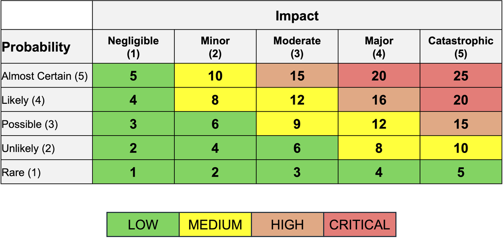

## Mapping Matrix Variables to ERM Domains (cont.)

**Financial Risk**

- **Specific Threat:** Funding Reductions from EHR Reporting Gaps
- **Risk Score:** Probability: **1** | Impact: **4** $\rightarrow$ **Total: 4 (Low)**
- **Mitigation Taxonomy:** **Create Contingency**
- **Informatics Vector:** Diversified secondary business intelligence data pipelines.

## Active Learning Exercise: Pandemic Surge Modelling

**Scenario: A new Virus Overwhelms the Ontario Health System**

**Your Task**

Work with your **peer**. Spend 10 minutes collaborating on mapping strategies, and be ready to present your matrix layout.

**Instructions:**

1. **Target 3 Distinct ERM Domains:** Select and define 3 distinct threats from your previous slide deck layout (e.g., *Ops.*, *Tech.*, or *Clinical & Patient Safety*).
2. **Assign Values:** Provide clear reasoning for your chosen Probability and Consequence scores based on current health system integration constraints.
3. **Deploy Digital Mitigation:** Propose 1 specific digital tool & specify if it functions as a **Preventative, Reduction, or Contingency** to drop your score by at least **2 bands**.

## Exercise Workspace: Blank Risk Matrix Grid

**Core Task:** Plot your chosen pandemic threat vectors onto this matrix:

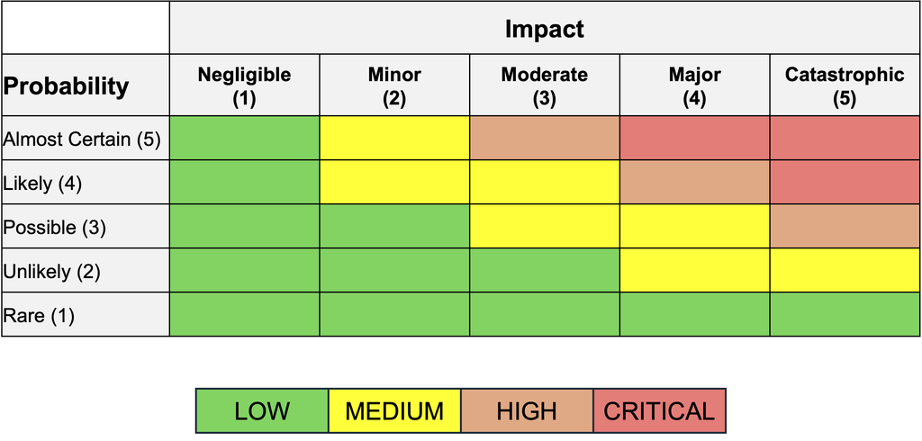

**Question**

How did your selected informatics solution mitigate overall system probability versus impact?

## Module 4.3

### Resilient Health Systems: Canadian Context

## Defining the Paradigm of Health System Resilience

**Shifting from Static Protection to Dynamic Adaptation**

- **The Core Concept:** A system’s capacity to absorb, adapt, and transform when faced with sudden, catastrophic shocks while maintaining core functions.
- **Theoretical Foundation:** Moving beyond *disaster management* to comprehensive systemic endurance.
- **Beyond Standard Definitions:** Resilience is not merely *snapping back* to a pre-crisis state; it requires structural evolution to withstand future economic and health system threats.
- **Value Anchor:** Resilient health systems actively shield population health outcomes from collapsing while preventing uncontrollable operational cost escalations.

**Source:** Kruk et al., 2015

## The Five Core Elements of a Resilient System

**System Design & Mapping**

1. **Aware:** Continuous, real-time tracking of clinical limits, supply, & workforce.
2. **Diverse:** Broad-spectrum service delivery & multi-layered physical assets.
3. **Self-Regulating:** Safety nets, testing feedback, & swift containment protocols.

**System Execution & Agility**

4. **Integrated:** Seamless communication between the care continuum & industry.
5. **Adaptive:** Flexibility to re-purpose assets, redeploy staff, & scale tools.

**The Governance Layer:**

- Force administrative decisions across centralized & decentralized partners.

**Source:** Haldane et al., 2021

## Resilience Capacities in the Canadian Context

**Operationalizing Resilience Capacities**

- **Absorptive:** The baseline ability to shield routine, essential care from being completely displaced by an active shock.
- **Adaptive:** Rapid step up regional surge capacity, shifting clinical cross-coverage, and activating cross-provincial resource sharing.
- **Transformative:** Codify crisis-driven insights into permanent legal, funding, and regulatory updates across ministries of health.

**Equity Imperative:**

- Ensure response strategies explicitly protect marginalized communities who face disproportionate health and economic vulnerability.

## The Dual-Lens Strategy for Canadian Resilience

**Balancing Public Equity Mandates with Private Sector Agility**

**The System Lens (Public Sector)**

- **Macro Equity Protection:** Preserve population-centred safety nets and adhering strictly to the CHA pillars.
- **Resource De-escalation:** Centralize the distribution of strategic reserves and balancing cross-regional patient loads based on societal equity.
- **Long-Term Risk Guardrails:** Align acute crisis decisions with Sustainable Development Goals.

**The Industry Lens (Private Sector)**

- **Micro-Level Efficiency:** Leverage market-driven supply chain networks to source critical inventory and PPE.
- **Rapid Tech Deployment:** Digital scaling up clinical automation, virtual platforms, and private laboratory diagnostics.
- **Fiscal Sustainability:** Structure public-private interfaces to keep health-sector innovators & vendors operationally viable.

## Module 4.4

### Aligning Sustainable Development Goals (SDGs)

## The SDG Framework: Systems Thinking for Global Health

[figure not shown]

## The SDG Framework: Systems Thinking for Global Health (cont.)

**A Blueprint for Shared Prosperity**

- **The 2030 Agenda:** Adopted by all UN Member States in 2015, the 17 Sustainable Development Goals (SDGs) provide a shared blueprint for peace, planet, and prosperity.
- **Beyond Clinical Care:** The framework explicitly recognizes that ending poverty and deprivation must go hand-in-hand with strategies that improve health and education.
- **The Informatics Imperative:** Tracking SDGs requires robust, standardized data infrastructure capable of measuring socio-ecological factors alongside clinical metrics.
- **A Systems Lens:** Health cannot be isolated; it is a downstream product of environmental stability, economic equity, and infrastructure resilience.

**Source:** [UN Sustainable Development Goals Knowledge Platform](https://sdgs.un.org/goals)

## Interconnectedness: The Nexus of Health, Wealth, & Climate

**Direct Health Targets: SDG 3**

- **Good Health and Well-Being:** Focuses on health outcomes, maternal mortality, epidemics, universal health coverage, and hazardous chemicals/pollution.
- **The Informatics Vector:** Leveraging population health data to predict disease surges and optimize healthcare resource allocation.

**The Multi-Goal Dependencies**

- **SDG 8 (Decent Work & Economic Growth):** Healthy workforces drive economic output; conversely, economic precarity increases acute health system strain.
- **SDG 13 (Climate Action):** Extreme weather events directly disrupt supply chains and fuel respiratory/cardiovascular admissions.
- **SDG 10 (Reduced Inequalities):** Health equity is unachievable without addressing systemic structural wealth and access gaps.

## The Canadian Landscape: Reconciling Policy & Performance

**Federal Mandates meets Provincial Execution**

- **The Federal Strategy:** Canada’s 2030 Agenda National Strategy establishes a clear federal commitment to achieving all 17 SDGs domestically.
- **The Decarbonization Challenge:** Canadian healthcare is carbon-intensive; if the global health sector were a country, it would be the fifth-largest emitter on earth.
- **Provincial Friction Points:** Healthcare delivery is a provincial jurisdiction (e.g., Ontario Health), meaning national SDG commitments must be translated into local hospital operational budgets.
- **Equity as a Metric:** Indigenous health disparities and rural/urban resource divides remain critical blind spots in standard Canadian health performance scorecards.

## Sector Dynamics: Public Mandates vs. Private Capital

**Navigating the Public-Private Interface**

- **The Public Sector Burden:** Publicly funded entities (e.g., OHT) bear the direct social and financial costs of failing to meet SDGs.
- **The Private Sector Engine:** Private life sciences companies, digital health startups, and supply vendors are increasingly judged on ESG (Environmental, Social, and Governance).
- **Procurement as a Lever:** Public health systems can mandate strict SDG compliance within their procurement pipelines, forcing private vendors to lower emissions.
- **The Shared Horizon:** True sustainability occurs when public policy goals and private sector incentives align to build resilient infrastructure.

## Interactive Exercise: SDG Alignment Sprint

**Active Learning Challenge: 10-Minute Strategy Sprint**

**Scenario:**

- Ontario Health is funding a major expansion of a digital hospital-at-home program designed to transition chronic heart failure patients out of physical acute-care beds.

**Your Task:**

1. Open your device and navigate to the official [UN Sustainable Development Goals Knowledge Platform](https://un.org).
2. Review the 17 goals and select **exactly three** interconnected SDGs (excluding SDG 3) that this specific virtual care expansion directly supports.
3. **Be ready to pitch:** As a healthcare executive, how would you pitch this program to a board by proving it hits environmental, economic, and health-equity goals simultaneously?

## Module 4 Summary: Sustainability & Risk

- **Funding & Payment Models:** Examined macroeconomic fiscal flows via the Canada Health Transfer, the private/public primary care mixed-payer spectrum, and the trade-offs of hospital global budgets.
- **Proactive Risk Management:** Shifted from reactive crisis mitigation to automated predictive surveillance using 5x5 enterprise risk matrices and EHR integration.
- **Resilient Health Systems:** Operationalized absorptive, adaptive, and transformative capacities across public equity mandates and private sector agility (Haldane et al., 2021; Kruk et al., 2015).
- **Sustainable Development Goals (SDGs):** Connected domestic health policy, carbon reduction, and multi-goal dependencies (SDGs 3, 8, 10, 13) to long-term system survival.

## Week 5 Deliverable: Capstone Written Brief (**Weight: 20%**)

- **Core Objective**: A professional 10-page executive report (2,000–2,500 words) detailing the Taskforce’s strategic public health and economic response.
- **Dual-Lens Integration**: Balances public health mandates with private-sector economic resilience and trade-offs using the DAEDALUS simulation interface.
- **Empirical Support**: Must incorporate at least **two (2) R-generated figures** derived directly from simulation outputs, following professional visualization standards.
- **Executive Standards**: Evaluated on bottom-line emphasis, structural clarity (headings/subheadings), neutral tone, and proper Vancouver-style citations.

**Full Requirements**

Refer to the course outline.